# Transitioning from SPSS to R - R-Ladies London

#### Explore

Running SPSS Explore on Price (limited screenshots because this is long output!):

- Descriptives

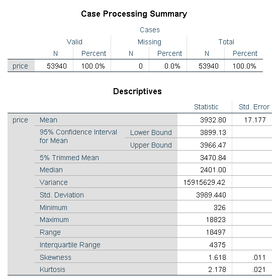

**Note:** Kurtosis is calculated differently between SPSS and R. Different kurtosis calculation methods are discussed [here](https://stats.stackexchange.com/questions/61740/differences-in-kurtosis-definition-and-their-interpretation).

```r
# Simple investigation of price

diamonds %>%
  summarize(n = n(), n_missing = sum(is.na(price)), mean = mean(price, na.rm = TRUE), sd = sd(price, na.rm = TRUE), min = min(price, na.rm = TRUE), max = max(price, na.rm = TRUE), median = median (price, na.rm = TRUE), IQR = IQR(price, na.rm = TRUE), variance = var(price, na.rm = TRUE), trimmed = mean(price, na.rm = TRUE, trim = 0.05), skewness = skewness(price, na.rm = TRUE), kurtosis = kurtosis(price, na.rm = TRUE)) %>%
  mutate(range = max - min) %>%
  mutate(stderror = sd/sqrt(n)) %>%
  mutate(confint_lower = mean-2*stderror) %>%
  mutate(confint_upper = mean+2*stderror)
```

```
## # A tibble: 1 x 16
##       n n_missing  mean    sd   min   max median   IQR variance trimmed
##   <int>     <int> <dbl> <dbl> <dbl> <dbl>  <dbl> <dbl>    <dbl>   <dbl>
## 1 53940         0 3933. 3989.   326 18823   2401 4374.   1.59e7   3471.
## # ... with 6 more variables: skewness <dbl>, kurtosis <dbl>, range <dbl>,
## #   stderror <dbl>, confint_lower <dbl>, confint_upper <dbl>
```

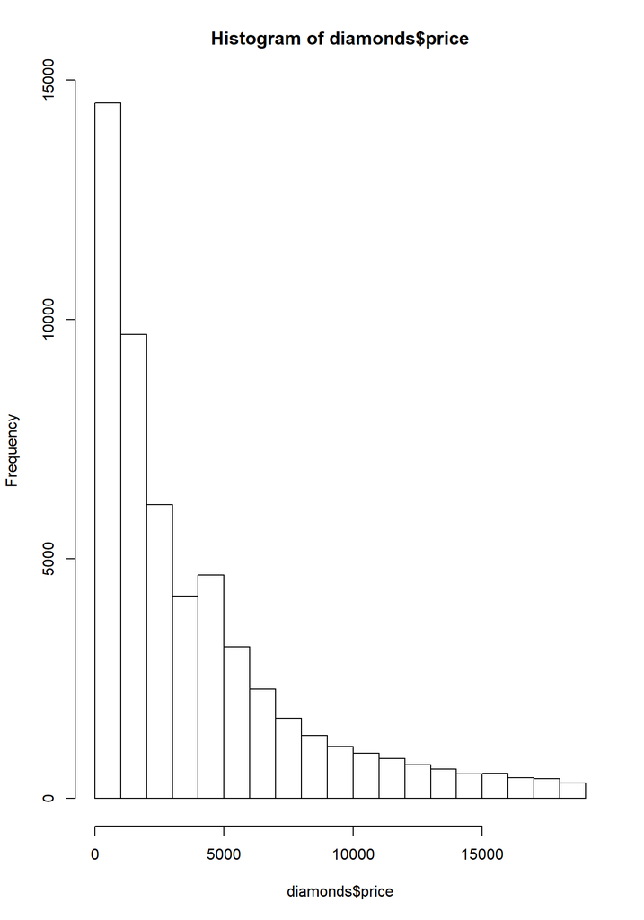

```r
hist(diamonds$price)
```

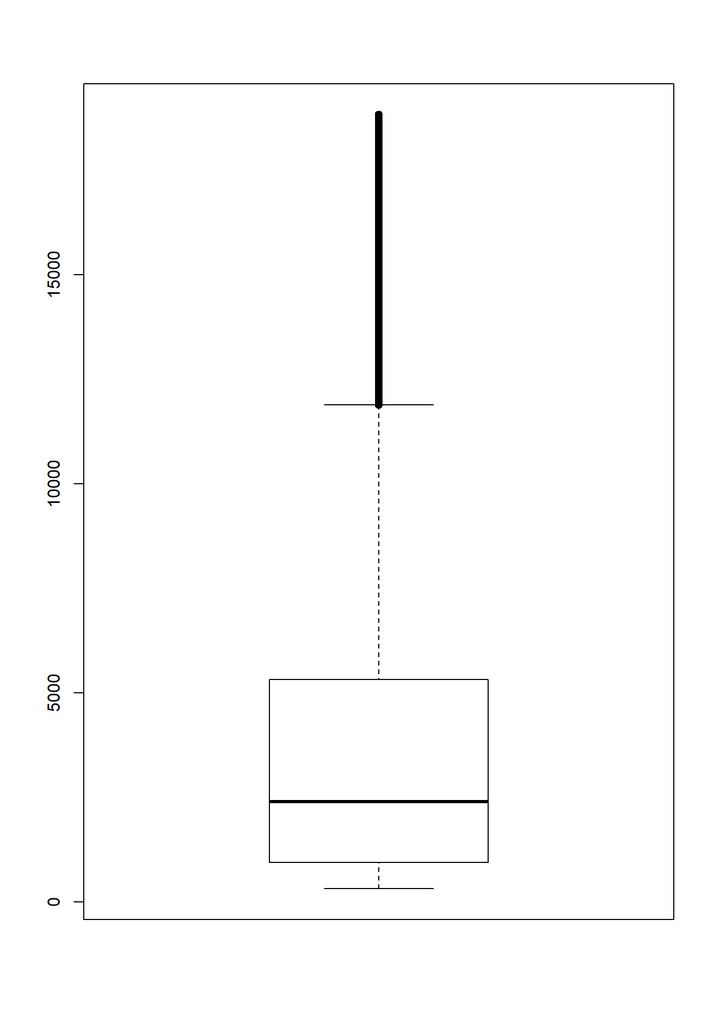

```r
boxplot(diamonds$price)
```

```r
# Price grouped by cut

diamonds %>%
  group_by(cut) %>%
  summarize(n = n(), n_missing = sum(is.na(price)), mean = mean(price, na.rm = TRUE), sd = sd(price, na.rm = TRUE), min = min(price, na.rm = TRUE), max = max(price, na.rm = TRUE), median = median (price, na.rm = TRUE), IQR = IQR(price, na.rm = TRUE), variance = var(price, na.rm = TRUE), trimmed = mean(price, na.rm = TRUE, trim = 0.05), skewness = skewness(diamonds$price, na.rm = TRUE), kurtosis = kurtosis(diamonds$price, na.rm = TRUE)) %>%
  mutate(range = max - min) %>%
  mutate(stderror = sd/sqrt(n)) %>%
  mutate(confint_lower = mean-2*stderror) %>%
  mutate(confint_upper = mean+2*stderror)
```

```
## # A tibble: 5 x 17
##   cut       n n_missing  mean    sd   min   max median   IQR variance
##   <ord> <int>     <int> <dbl> <dbl> <dbl> <dbl>  <dbl> <dbl>    <dbl>
## 1 Fair   1610         0 4359. 3560.   337 18574  3282  3155.   1.27e7
## 2 Good   4906         0 3929. 3682.   327 18788  3050. 3883    1.36e7
## 3 Very~ 12082         0 3982. 3936.   336 18818  2648  4461.   1.55e7
## 4 Prem~ 13791         0 4584. 4349.   326 18823  3185  5250    1.89e7
## 5 Ideal 21551         0 3458. 3808.   326 18806  1810  3800.   1.45e7
## # ... with 7 more variables: trimmed <dbl>, skewness <dbl>,
## #   kurtosis <dbl>, range <dbl>, stderror <dbl>, confint_lower <dbl>,
## #   confint_upper <dbl>
```

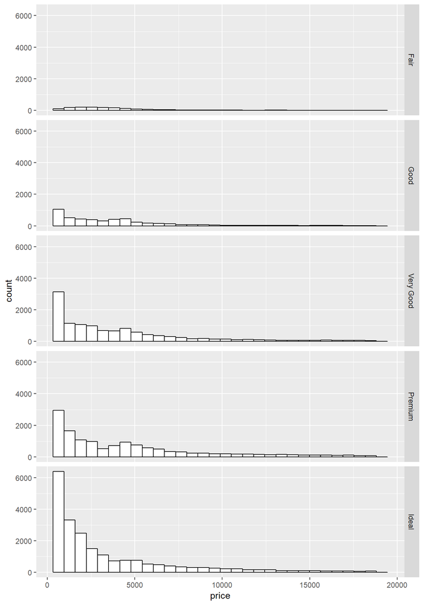

```r
ggplot(diamonds, aes(x = price)) +
  geom_histogram(color = "black", fill = "white") +
  facet_grid(cut ~.)
```

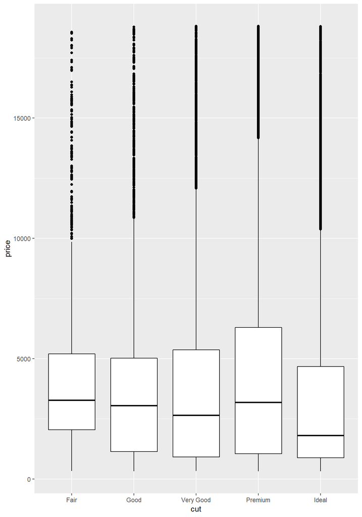

```r
ggplot(diamonds, aes(x = cut, y = price)) +
  geom_boxplot(color = "black", fill = "white")
```

### Questionnaires?

Working with questionnaire data offers unique challenges. For those of you who are into that, here are some quick tips on how to manage this kind of data.

We’re going to use the `bfi` dataset - documentation can tell you lots about it! The `bfi` documentation actually includes a sample of how to use an item key and score negatively keyed items - so this section is us working through the provided sample. In SPSS, you would negatively key items using Transform.

Briefly, `bfi` is a set of 25 personality self-report items from 2800 subjects, plus demogrpahics on gender, education, and age. The 25 items are oranized around 5 factors: (A) Agreeableness, (C) Conscientiousness, (E) Extraversion, (N) Neuroticism, (O) Openness. As is common with questionnaire data, some of these items are negatively keyed (ie. high scores on the question represent low levels of the dimension measured). This is easy to do in R! To make a keys.list, define vectors for each factor (ie. Agreeableness) and list the included questions by name. Negatively keyed variables are prefaced with a -.

```r
data(bfi)
glimpse(bfi)
## Observations: 2,800
## Variables: 28
## $ A1        <int> 2, 2, 5, 4, 2, 6, 2, 4, 4, 2, 4, 2, 5, 5, 4, 4, 4, 5...
## $ A2        <int> 4, 4, 4, 4, 3, 6, 5, 3, 3, 5, 4, 5, 5, 5, 5, 3, 6, 5...
## $ A3        <int> 3, 5, 5, 6, 3, 5, 5, 1, 6, 6, 5, 5, 5, 5, 2, 6, 6, 5...
## $ A4        <int> 4, 2, 4, 5, 4, 6, 3, 5, 3, 6, 6, 5, 6, 6, 2, 6, 2, 4...
## $ A5        <int> 4, 5, 4, 5, 5, 5, 5, 1, 3, 5, 5, 5, 4, 6, 1, 3, 5, 5...
## $ C1        <int> 2, 5, 4, 4, 4, 6, 5, 3, 6, 6, 4, 5, 5, 4, 5, 5, 4, 5...
## $ C2        <int> 3, 4, 5, 4, 4, 6, 4, 2, 6, 5, 3, 4, 4, 4, 5, 5, 4, 5...
## $ C3        <int> 3, 4, 4, 3, 5, 6, 4, 4, 3, 6, 5, 5, 3, 4, 5, 5, 4, 5...
## $ C4        <int> 4, 3, 2, 5, 3, 1, 2, 2, 4, 2, 3, 4, 2, 2, 2, 3, 4, 4...
## $ C5        <int> 4, 4, 5, 5, 2, 3, 3, 4, 5, 1, 2, 5, 2, 1, 2, 5, 4, 3...
## $ E1        <int> 3, 1, 2, 5, 2, 2, 4, 3, 5, 2, 1, 3, 3, 2, 3, 1, 1, 2...
## $ E2        <int> 3, 1, 4, 3, 2, 1, 3, 6, 3, 2, 3, 3, 3, 2, 4, 1, 2, 2...
## $ E3        <int> 3, 6, 4, 4, 5, 6, 4, 4, NA, 4, 2, 4, 3, 4, 3, 6, 5, ...
## $ E4        <int> 4, 4, 4, 4, 4, 5, 5, 2, 4, 5, 5, 5, 2, 6, 6, 6, 5, 6...
## $ E5        <int> 4, 3, 5, 4, 5, 6, 5, 1, 3, 5, 4, 4, 4, 5, 5, 4, 5, 6...
## $ N1        <int> 3, 3, 4, 2, 2, 3, 1, 6, 5, 5, 3, 4, 1, 1, 2, 4, 4, 6...
## $ N2        <int> 4, 3, 5, 5, 3, 5, 2, 3, 5, 5, 3, 5, 2, 1, 4, 5, 4, 5...
## $ N3        <int> 2, 3, 4, 2, 4, 2, 2, 2, 2, 5, 4, 3, 2, 1, 2, 4, 4, 5...
## $ N4        <int> 2, 5, 2, 4, 4, 2, 1, 6, 3, 2, 2, 2, 2, 2, 2, 5, 4, 4...
## $ N5        <int> 3, 5, 3, 1, 3, 3, 1, 4, 3, 4, 3, NA, 2, 1, 3, 5, 5, ...
## $ O1        <int> 3, 4, 4, 3, 3, 4, 5, 3, 6, 5, 5, 4, 4, 5, 5, 6, 5, 5...
## $ O2        <int> 6, 2, 2, 3, 3, 3, 2, 2, 6, 1, 3, 6, 2, 3, 2, 6, 1, 1...
## $ O3        <int> 3, 4, 5, 4, 4, 5, 5, 4, 6, 5, 5, 4, 4, 4, 5, 6, 5, 4...
## $ O4        <int> 4, 3, 5, 3, 3, 6, 6, 5, 6, 5, 6, 5, 5, 4, 5, 3, 6, 5...
## $ O5        <int> 3, 3, 2, 5, 3, 1, 1, 3, 1, 2, 3, 4, 2, 4, 5, 2, 3, 4...
## $ gender    <int> 1, 2, 2, 2, 1, 2, 1, 1, 1, 2, 1, 1, 2, 1, 1, 1, 2, 1...
## $ education <int> NA, NA, NA, NA, NA, 3, NA, 2, 1, NA, 1, NA, NA, NA, ...
## $ age       <int> 16, 18, 17, 17, 17, 21, 18, 19, 19, 17, 21, 16, 16, ...

keys.list <- list(agree=c("-A1","A2","A3","A4","A5"),conscientious=c("C1","C2","C3","-C4","-C5"),
extraversion=c("-E1","-E2","E3","E4","E5"),neuroticism=c("N1","N2","N3","N4","N5"),
openness = c("O1","-O2","O3","O4","-O5"))

# scoreItems gives a ton of info about items!
scores <- scoreItems(keys.list,bfi,min=1,max=6) # Need to specify the minimum and maximum values
scores
```

```
## Call: scoreItems(keys = keys.list, items = bfi, min = 1, max = 6)
##
## (Unstandardized) Alpha:
##       agree conscientious extraversion neuroticism openness
## alpha   0.7          0.72         0.76        0.81      0.6
##
## Standard errors of unstandardized Alpha:
##       agree conscientious extraversion neuroticism openness
## ASE   0.014         0.014        0.013       0.011    0.017
##
## Average item correlation:
##           agree conscientious extraversion neuroticism openness
## average.r  0.32          0.34         0.39        0.46     0.23
##
## Median item correlation:
##         agree conscientious  extraversion   neuroticism      openness
##          0.34          0.34          0.38          0.41          0.22
##
##  Guttman 6* reliability:
##          agree conscientious extraversion neuroticism openness
## Lambda.6   0.7          0.72         0.76        0.81      0.6
##
## Signal/Noise based upon av.r :
##              agree conscientious extraversion neuroticism openness
## Signal/Noise   2.3           2.6          3.2         4.3      1.5
##
## Scale intercorrelations corrected for attenuation
##  raw correlations below the diagonal, alpha on the diagonal
##  corrected correlations above the diagonal:
##               agree conscientious extraversion neuroticism openness
## agree          0.70          0.36         0.63      -0.245     0.23
## conscientious  0.26          0.72         0.35      -0.305     0.30
## extraversion   0.46          0.26         0.76      -0.284     0.32
## neuroticism   -0.18         -0.23        -0.22       0.812    -0.12
## openness       0.15          0.19         0.22      -0.086     0.60
##
##  In order to see the item by scale loadings and frequency counts of the data
##  print with the short option = FALSE
```

```r
# Call str() on scores to see all the pieces of information you can access
# individually! The *scores* element of scores includes the re-keyed items
# Summarise from dplyr can help you investigate these scores.
keyed_scores <- data.frame(scores$scores)

keyed_scores %>%
  summarise_all(mean)
```

```
##    agree conscientious extraversion neuroticism openness
## 1 4.6531        4.2694        4.146       3.162    4.591
```

```r
# If you wanted to group by a variable (such as gender) - remember that
# we dropped demographics when we used keys.list. We can get those back!
# According to the documentation, males = 1 and females =2
keyed_scores <- cbind(gender = bfi$gender, keyed_scores)

keyed_scores %>%
  group_by(gender) %>%
  summarise_all(mean)
```

```
## # A tibble: 2 x 6
##   gender agree conscientious extraversion neuroticism openness
##    <int> <dbl>         <dbl>        <dbl>       <dbl>    <dbl>
## 1      1  4.39          4.14         3.99        2.95     4.66
## 2      2  4.78          4.33         4.22        3.27     4.56
```

```r
# Using dplyr::select to help you subset to look at individual pieces of the data
open <- bfi %>%
  select(starts_with("O"))
```

Dummy coding is useful and not exclusive to questionnaire data. This is very simple in R. Let’s say we wanted to look at the relationship between education and openness.

```r
# Factor the variable first mostly to re-label nicely
factored_edu <- factor(bfi$education, labels = c("someHS", "doneHS", "someCollege", "doneCollege", "graduate"), ordered = TRUE, exclude = NA)

edu <- dummy.code(factored_edu)

# Your dummy coded variables are now an island!
# Bind these dummy coded education variables to the openness df
# we made earlier with dplyr::select.
open_edu <- cbind(edu, open)
```

### Links

#### Basics, Importing, Wrangling

- https://datacarpentry.org/R-genomics/index.html
- https://www.statmethods.net/input/importingdata.html
- https://www.datacamp.com/community/tutorials/r-data-import-tutorial
- https://rpubs.com/williamsurles/292547
- http://stcorp.nl/R_course/tutorial_dplyr.html

#### Questionnaires/Surveys

- https://mvuorre.github.io/toolbox/questionnaire.html

#### Stats

- http://www.milanor.net/blog/aggregation-dplyr-summarise-summarise_each/
- http://www.r-tutor.com/elementary-statistics
- http://tutorials.iq.harvard.edu/R/Rstatistics/Rstatistics.html
- http://r-statistics.co/Assumptions-of-Linear-Regression.html
- http://www.statmethods.net/stats/anova.html
- http://myowelt.blogspot.ca/2008/05/obtaining-same-anova-results-in-r-as-in.html
- http://www.sthda.com/english/wiki/correlation-matrix-a-quick-start-guide-to-analyze-format-and-visualize-a-correlation-matrix-using-r-software
- https://www.r-bloggers.com/example-2014-6-comparing-medians-and-the-wilcoxon-rank-sum-test/
- http://gribblelab.org/stats/index.html
- ftp://public.dhe.ibm.com/software/analytics/spss/documentation/statistics/24.0/en/client/Manuals/IBM_SPSS_Statistics_Algorithms.pdf

#### Summary Documents

- https://bookdown.org/yihui/rmarkdown/
- https://www.rstudio.com/wp-content/uploads/2015/03/rmarkdown-reference.pdf
- https://davidgohel.github.io/flextable/articles/overview.html
- https://cran.r-project.org/web/packages/flextable/vignettes/format.html
- https://cran.r-project.org/web/packages/flextable/flextable.pdf
- https://cran.r-project.org/web/packages/captioner/vignettes/using_captioner.html
- https://cran.r-project.org/web/packages/kableExtra/vignettes/awesome_table_in_html.html

Thanks for reading/listening!